# Going to France: Accomodation in a Student Residence

the first labyrinth

french bureaucracy

going to France

Published

September 25, 2021

> Get ready to read this post many times at different moments of the procedure

Getting accomodation in a Student Residence was my first experience with a French public service working within France…. and d*mn was it convoluted. Too many steps were only explained in French, some staff could not communicate in English, and the system itself sometimes doesn’t make sense.

This is one of the information labytinths I mentioned [before](https://luisavasquez.github.io/quiescens-lct/posts/2021-08-10-migration-advise.html#information-labyrinths).

In this post, I will tell you how *I* did it, try to clarify some concepts, recount some issues I found along the way, and explain what was different for Erasmus Mundus students.

> All of this was done **in parallel** to the Visa Application process

[figure not shown]

# Whas is CROUS?

In France, Universities and Institutes do not manage the Student Residences, they are managed by **CROUS**.

CROUS is the French public institution in charge of: - Student Residences - University dining halls - Cafeterias - Sports facilities - Some leisure events like concerts or art expositions

You will make your application for a Student Residence to CROUS, you will pay your rent to CROUS, have your student lunch at CROUS dining halls, practice sports at CROUS facilities, etc.

You will be dealing with [CROUS Lorraine](https://www.crous-lorraine.fr/). You can find their catalogue of residences (including prices) [here](https://www.crous-lorraine.fr/logements/nos-loyers/).

# Student Guide

The system is so weird, that the Université de Lorraine provides a guide in it’s [Website for international students](https://welcome.univ-lorraine.fr/), called `Pas a Pas CROUS`. Sometimes it is not easy to find in the website itself, so just Google `universite de lorraine exchange student crous residence guide` to find it.

You may think that this guide is complicated and not user friendly, but trust me, they are explaining the system in the simplest and most practical way possible.

Take a look at the overview of the process of applying to a university residence:

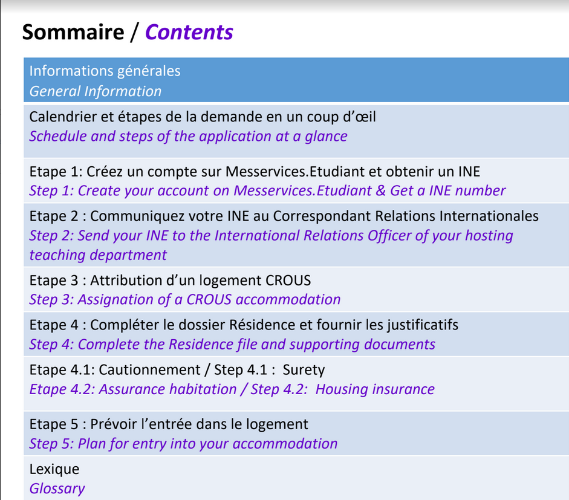

> You can find *my* copy [here](https://drive.google.com/file/d/18603Jwf5hisxCCl2xjOJ19he3e6eq1KU/view?usp=drive_link)

Note that these instructions may have changed.

### Some advise

Read the guide carefully, but don’t panic. As you will see while you read this post. It *is* possible to overcome all the bureaucratic juggles and deadends, and having the local LCT Coordinator on your side helps a lot.

# The first steps in the application process

Creating the account at `Messervices.Etudiant` is the first step. They will request the following documents:

- Campus France Certificate (*Accord préalable*)
- Admission letter from the Université de Lorraine
- Erasmus Mundus scholarship letter
- Passport

After creating the account, you will get an INE: The INE is a number identifying you as a French student, and will be used to track your application. You will get it just after creating an account at `Messervices.etudiant`.

Wait some months, in my case, it was until almost the end of July, and if the CROUS accepted your application into a residence, you will have to pay **100€** *within a week of receiving the news* to reserve your place!

## Some issues I had

- I couldn’t create my account at `Messervices.Etudiant` for many weeks because it expected a French phone number. I wrote emails to their helpdesk but never got a response. I asked around a lot and no one knew what to do. Eventually and miraculously, the website had a redesign, and it didn’t ask me for a French phone number anymore, so I could finally create my account.
- Exchange rates suck for paying in Euros in my local currency. They are better if you get a local account in USD, and even better if you can get a local account in Euros (I managed to get an account in Euros in my country but it didn’t allow for online payments).

# Explaining the *Garant* and the *Cautionemment*

You will see these terms everywhere when you try to look for information on getting a CROUS residence. Here’s what’s necessary to know from a practical point of view.

The *Garant* is the person or institution who backs up your application financially: if you don’t pay your rent, they will charge it to the *Garant*.

A person or institution expresses their desire to become your *Garant* by writting a *Cautionemment* agreement.

Simple, but no one takes the time to explain it.

### What is Visale? Is it worth it?

Wherever you look for information about getting a CROUS residence, people will recommend you to use “Visale”. Even the guide mentioned before lists it as the first option for a *Garant*.

> Don’t rush to get Visale!

[Visale](https://www.visale.fr/) is a service of the French government. Students who get Visale have the French State as their *Garant*.

#### The Visale loophole

[figure not shown]

There is a particular situation preventing most foreign students to get Visale:

> **Applying to Visale as a foreigner requires a French Visa**

I mentioned in a [previous post](https://luisavasquez.github.io/quiescens-lct/posts/2021-09-21-french-visa-2.html#option-3-proof-of-acceptance-into-a-student-residence) that one option (“Option 3” in the post) for getting the proof of accomodation necessary for the Visa had a loophole. This is it.

If you try to go for Option 3, you will be in the following situation:

- To get a French Visa you need to show a proof of accomodation
- Option 3 means that your proof of accomodation will be the proof of acceptance into a CROUS Student Residence
- Acceptance into a CROUS Student Residence requires a *Garant*
- To get Visale as *Garant*, you need a French Visa

[figure not shown]

#### Breaking the loophole

After asking around to several past exchange students to France, within and outside Erasmus programs, apparently this is an issue that everyone encounters, which, I will add, makes it even more ridiculuous.

The way to break the loophole is to get a *Garant* that is not Visale. See the section below about special conditions for Erasmus Mundus students.

# In my particular case

After having payed the 100€, I received the list of documents I had to send to my Residence (but ultimately couldn’t. See the section below about special conditions for Erasmus Students).

## 1 *Reglement interieur* and *Conditions Particulières*

These documents are basically the rules of good conduct of the residence. I printed them, put my initials on every page, signed them, and scanned them into a PDF.

## 2 *Décision d’admission*

This is the document where the CROUS tells you are in the “pre-accepted” to get a room, and explain you some administrative rooms. I printed it, put my initials on every page, signed it, and scanned it into a PDF.

## 3 *Caution locative*

This is the document declaring who is your *Garant*. See the section below about special conditions for Erasmus Mundus students.

## 4 Identity and Bank account

This is a copy of your passport, together with a Bank account number. If you are not european, you probably don’t have a bank account in the European system [IBAN](https://en.wikipedia.org/wiki/International_Bank_Account_Number).

**Provitionally** they accepted my local bank account, but it is **mandatory** to provide them with an IBAN as soon as possible.

What I did was to get my local bank account number in a format suitable for international transfers, together with my bank’s [SWIFT-BIC code](https://en.wikipedia.org/wiki/ISO_9362), and wrote a letter like this:

```python
"""
Messieurs du CROUS de Lorraine,
Je vous écrive cette lettre pour vous informer de mon relevé d’identité bancaire.
Dans ma condition d’étudiant étranger dans un programme Erasmus Mundus Master,
j’utiliserai ce-relevé-ci jusqu’à je prenne un compte bancaire en France. Après ça, je vais mettre à jour mes données.
SWIFT :
<My Bank's SWIRF>
Compte :
<My Bank account number>

Cordialement,
<My Name>
INE <My INE>
""";
```

which would be translated along the lines of:

```python
"""
Gentlemen from the CROUS Lorraine,

I write you this letter to inform you of my bank account number.
In my condition of foreing student in a Erasmus Mundus Master progra,
I will use this banc account until I get a bank account in France.
After that, I will update my information.

SWIFT :
<My Bank's SWIRF>
Account :
<My Bank account number>

Greetings,
<My Name>
INE <My INE>
""";
```

## 5 Insurance

**House insurance** is necessary to cover for damages in your own room. However, the CROUS requires a house insurance scheme that also includes **Civil insurance**, which covers possible damages you could make to the property of others.

There are many options, and after searching for a while I settled for a friend’s recommendation of using [ADH Assurance étudiants](https://www.assurances-etudiants.com/). It cost me around **30€ for a whole year**, and it took me around 3 hours to set up and get a *Attestation d’Assurance* (Insurance Certificate).

## 6 *Renseigement* / Personal information

I printed it, signed it, and scanned it into a PDF.

## 7 *Charte informatique*

This is simply a document saying you will make responsible use of the internet at the Residence. I printed it, put my initials on every page, signed it, and scanned it into a PDF.

# For Erasmus Mundus students

Some things where different for Erasmus Mundus students

## Help from the Coordinator

The local LCT Coordinator at the Université de Lorraine helped us along the way. Months before our departure to France, he sent us some tables to fill with our preferences for a CROUS residence. At the end of the process, these where not that important because **all the LCT students (both year 1 and year 2) got assigned to the same CROUS residence**.

For my batch, this was [Residence Batelière](https://www.crous-lorraine.fr/logements/visites-virtuelles/bateliere/).

I have heard that in other years, LCT students have all been assigned to [Residence Boudonville](https://www.crous-lorraine.fr/logements/visites-virtuelles/boudonville/).

> In my batch at the Université de Lorraine, **all** LCT students got a CROUS residence, independent of whether or not they had a scholarship.

### Getting a *Garant* for the *Cautionnement*

The biggest help from the local LCT Coordinator was to determine who was going to be our *Garant*. The IDMC became our *Garant*, and the Coordinator sent us documents to include in the files we had to send by email.

## In the system, but not really

Some days after having payed the 100€ to reserve a room, I got an email saying I had to send the documents enumerated above to my Residence within a week to get my final confirmation.

As we found out, this didn’t work for us: they expected the documents to be sent by **physical mail**! Ridiculuous.

We took this up with the local LCT Coordinator, because there was no way for us to make it before the deadline (withouth paying a lot for a express post service, and even then, we would have to cross our fingers). Add to this the problem of being in the middle of the pandemic.

Eventually, the Coordinator managed to find an alternative process for us. We had to mail the files directly to the email of the Residence Batelière. We did it, but then they were taking long to answer and our travel dates where approaching, so one of the LCT students managed to find out who was in charge of assigning the rooms at the Residence Batelière, and we sent our files to that person. In a couple of days we got our final confirmations of acceptance into a CROUS residence.

> Note that I got my proof of acceptance into a CROUS residence **after** getting my French Visa.

# Arriving earlier

My Residence gave me the option of arriving earlier than the official start of my contract (which was the 1st of September of 2021).

In order to take this option, each of the extra days must be payed when you arrive (they tell you the price per night in an email). I took advantage of this and told them I would arrive a week earlier, at the end of August 2021.

> Even if you don’t arrive earlier, it is necessary to schedule an appointment (via email) to pick up the keys in person. **Check the opening hours of the reception office at the residence!**

# More to do after arriving to the residence

Eventually, you have to give some additional documents to the administration at your residence.

- Proof of enrollment in the Université de Lorraine (*Certificat d’escolarité*)
- IBAN Banc account number

> You must pay a deposit when you pick up the keys. They accept payment by cash or by a European credit or debit card.

The payment is done at the Residence’s reception office just next to the main entrance.

Because I had no European bank account, I payed by cash. Note that this is the only payment they accept by cash, all posterior rent payments have to be done by card.